# 0) Import necessary modules

```python
from tensorflow.keras.preprocessing.image import ImageDataGenerator
from tensorflow.keras.preprocessing import image
from tensorflow.keras.optimizers import RMSprop
import matplotlib.pyplot as plt
import tensorflow as tf
import numpy as np
import cv2 as cv
import os
import numpy as np
import scipy
```

```python
# Control gpu memory
import tensorflow as tf
gpus = tf.config.experimental.list_physical_devices('GPU')
for gpu in gpus:
  tf.config.experimental.set_memory_growth(gpu, True)
```

```python
# Set random seed for reproducibility
np.random.seed(1)
```

# 1) Background research and exploratory data analysis

Before, I start loading datasets, I went to check through each image folder and realised that the image in training beans folder had carrot images inside which is wreongly classfied.

# a) File analysis

```python
os.chdir("C:\\Users\\User\\Downloads\\CA1\\CA1\\Dataset for CA1 part A - AY2425S1")
```

```python
extension_counts = {}

# Function to iterate through folders and count extensions
def count(folder):
    for dirpath, _, filenames in os.walk(folder):
        for filename in filenames:
            _, ext = os.path.splitext(filename)
            if ext:
                ext = ext.lower()
                if ext in extension_counts:
                    extension_counts[ext] += 1
                else:
                    extension_counts[ext] = 1

# Iterate through every folder in CA1 Dataset
for folder_name in os.listdir("C:\\Users\\User\\Downloads\\CA1\\CA1\\Dataset for CA1 part A - AY2425S1"):
    folder_path = os.path.join("C:\\Users\\User\\Downloads\\CA1\\CA1\\Dataset for CA1 part A - AY2425S1", folder_name)
    if os.path.isdir(folder_path):
        count(folder_path)

# Display the count of each extension
for ext, count in extension_counts.items():
    print(f"{ext}: {count}")

# Calculate and display the total number of images
total_images = sum(extension_counts.values())
print("Total Images:", total_images)
```

```
.jpg: 15043
Total Images: 15043
```

All file images are in jpg, so we do not need to worry about the file extension

# b) First Image Analysis

```python
# Intialise img to first train image (Bean)

img = image.load_img("train\\Bean\\0026.JPG")
```

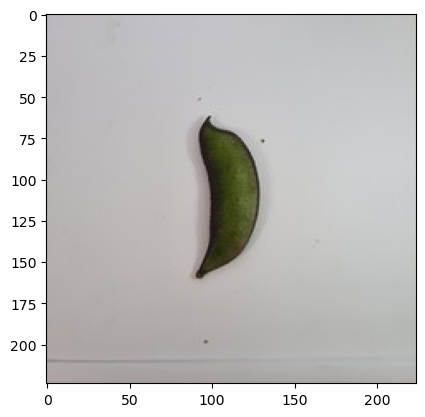

```python
# Show image
plt.imshow(img)
```

```python
# Show the shape of the image
cv.imread("train\\Bean\\0026.JPG").shape
```

```
(224, 224, 3)
```

This image contain 224 pixel by 224 pixel with 3 channel. We want to convert them into 37 by 37 pixel and 131 pixel by 131 pixel, both with 1 channel.

# 2) Feature engineering

```python
# normalize the pixel values of images to a range between 0 and 1

# Normalisation
normalize = ImageDataGenerator(rescale=1/255)
```

Split train, val, test into train_dataset_37, validation_dataset_37, train_dataset_37.

# a) 37 by 37 pixels

## a i) Preprocess images

First, we normalize the dataset and convert images into 37 by 37 pixel.

```python
# train_dataset_37
train_dataset_37 = normalize.flow_from_directory('train',target_size=(37,37),
        color_mode='grayscale',
        batch_size=10000,
        class_mode='categorical')

# val_dataset_37
val_dataset_37 = normalize.flow_from_directory('validation',target_size=(37,37),
        color_mode='grayscale',
        batch_size=5000,
        class_mode='categorical')

# test_dataset_37
test_dataset_37 = normalize.flow_from_directory('validation',target_size=(37,37),
        color_mode='grayscale',
        batch_size=5000,
        class_mode='categorical')
```

```
Found 9035 images belonging to 15 classes.
Found 3000 images belonging to 15 classes.
Found 3000 images belonging to 15 classes.
```

We want to see the class indices that every datasets have in 37 by 37 pixel.

```python
# Show the class indices

# Train
print(f'Train:\n {train_dataset_37.class_indices}')

# Validation
print(f'\nValidation:\n {val_dataset_37.class_indices}')

# Test
print(f'\nTest:\n {test_dataset_37.class_indices}')
```

```
Train:
 {'Bean': 0, 'Bitter_Gourd': 1, 'Bottle_Gourd': 2, 'Brinjal': 3, 'Broccoli': 4, 'Cabbage': 5, 'Capsicum': 6, 'Carrot': 7, 'Cauliflower': 8, 'Cucumber': 9, 'Papaya': 10, 'Potato': 11, 'Pumpkin': 12, 'Radish': 13, 'Tomato': 14}

Validation:
 {'Bean': 0, 'Bitter_Gourd': 1, 'Bottle_Gourd': 2, 'Brinjal': 3, 'Broccoli': 4, 'Cabbage': 5, 'Capsicum': 6, 'Carrot': 7, 'Cauliflower': 8, 'Cucumber': 9, 'Papaya': 10, 'Potato': 11, 'Pumpkin': 12, 'Radish': 13, 'Tomato': 14}

Test:
 {'Bean': 0, 'Bitter_Gourd': 1, 'Bottle_Gourd': 2, 'Brinjal': 3, 'Broccoli': 4, 'Cabbage': 5, 'Capsicum': 6, 'Carrot': 7, 'Cauliflower': 8, 'Cucumber': 9, 'Papaya': 10, 'Potato': 11, 'Pumpkin': 12, 'Radish': 13, 'Tomato': 14}
```

## a ii) Show whether there is any class imbalance

```python
# Show the classes

# Train
print(f'Train:\n {train_dataset_37.classes}')

# Validation
print(f'\nValidation:\n {val_dataset_37.classes}')

# Test
print(f'\nTest:\n {test_dataset_37.classes}')
```

```
Train:
 [ 0  0  0 ... 14 14 14]

Validation:
 [ 0  0  0 ... 14 14 14]

Test:
 [ 0  0  0 ... 14 14 14]
```

### Train Dataset

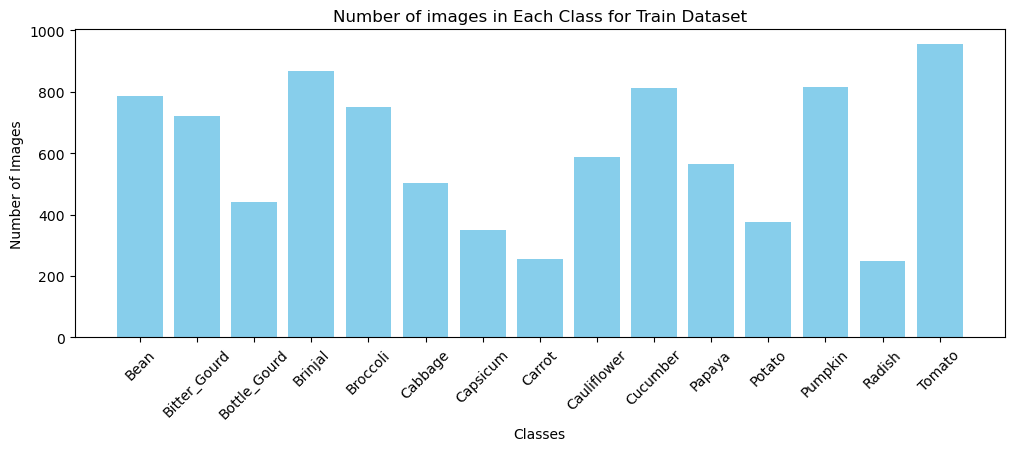

```python
# Get the class indices
class_indices_train = train_dataset_37.class_indices

# Store a count of items in each class
class_count_train = {class_name: 0 for class_name in class_indices_train.keys()}

# Directory containing the training data
train_dir = 'train'

for class_name in os.listdir(train_dir):
    class_path = os.path.join(train_dir, class_name)
    if os.path.isdir(class_path):
        class_count_train[class_name] = len(os.listdir(class_path))

# Plot graph
plt.figure(figsize=(12, 4))
plt.bar(class_count_train.keys(), class_count_train.values(), color='skyblue')
plt.xlabel('Classes')
plt.ylabel('Number of Images')
plt.title('Number of images in Each Class for Train Dataset')
plt.xticks(rotation=45)
plt.show()
```

We can see that there is some class imbalance

### Validation Dataset

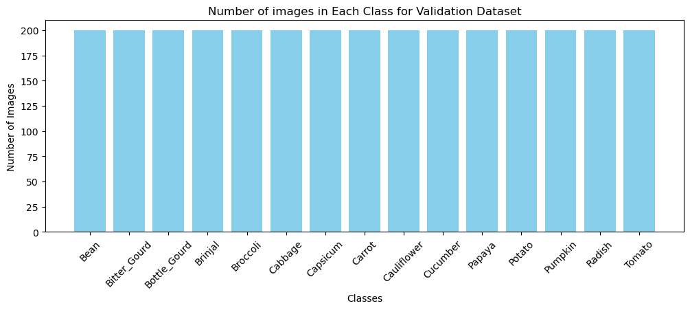

```python
# Get the class indices validation dataset
class_indices_val = val_dataset_37.class_indices

# Store a count of items in each class
class_count_val = {class_name: 0 for class_name in class_indices_val.keys()}

# Directory containing the training data
val_dir = 'validation'

for class_name in os.listdir(val_dir):
    class_path = os.path.join(val_dir, class_name)
    if os.path.isdir(class_path):
        class_count_val[class_name] = len(os.listdir(class_path))

# Plot graph
plt.figure(figsize=(12, 4))
plt.bar(class_count_val.keys(), class_count_val.values(), color='skyblue')
plt.xlabel('Classes')
plt.ylabel('Number of Images')
plt.title('Number of images in Each Class for Validation Dataset')
plt.xticks(rotation=45)
plt.show()
```

We can see that there is no class imbalance

### Test Dataset

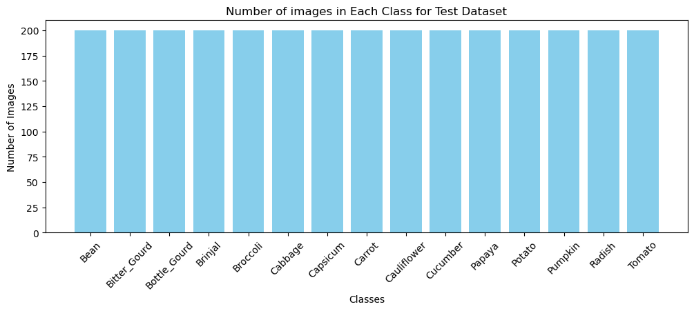

```python
# Get the class indices
class_indices_test = test_dataset_37.class_indices

# Store a count of items in each class
class_count_test = {class_name: 0 for class_name in class_indices_test.keys()}

# Directory containing the test data
test_dir = 'test'

for class_name in os.listdir(test_dir):
    class_path = os.path.join(test_dir, class_name)
    if os.path.isdir(class_path):
        class_count_test[class_name] = len(os.listdir(class_path))

# Plot graph
plt.figure(figsize=(12, 4))
plt.bar(class_count_test.keys(), class_count_test.values(), color='skyblue')
plt.xlabel('Classes')
plt.ylabel('Number of Images')
plt.title('Number of images in Each Class for Test Dataset')
plt.xticks(rotation=45)
plt.show()
```

We can see that there is no class imbalance

Since, there is class imbalance for 37 pixel for training set, there will be class imbalance for 131 pixel too. We will deal with that after we split the train validation test

## a iii) Convert train, validation and test dataset into X_train, y_train, X_val, y_val, X_test, y_test

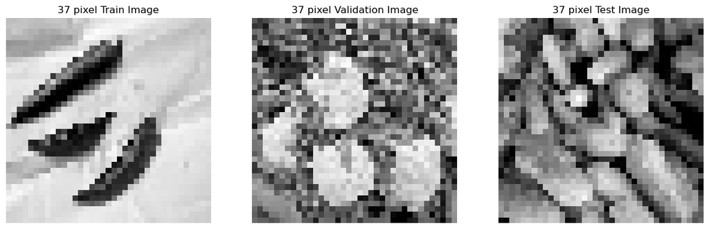

```python
# Get image from the train_dataset_37
X_train_37, y_train_37 = next(train_dataset_37)

# Get image from the validation_dataset_37
X_val_37, y_val_37 = next(val_dataset_37)

# Get image from the test_dataset_37
X_test_37, y_test_37 = next(test_dataset_37)

fig, ax = plt.subplots(1, 3, figsize=(15, 5))

# Display the first image for train, val and test
ax[0].imshow(X_train_37[0], cmap = 'gray')
ax[0].set_title('37 pixel Train Image')


ax[1].imshow(X_val_37[0], cmap = 'gray')
ax[1].set_title('37 pixel Validation Image')

ax[2].imshow(X_test_37[0], cmap = 'gray')
ax[2].set_title('37 pixel Test Image')


ax[0].axis('off')
ax[1].axis('off')
ax[2].axis('off')

plt.show()
```

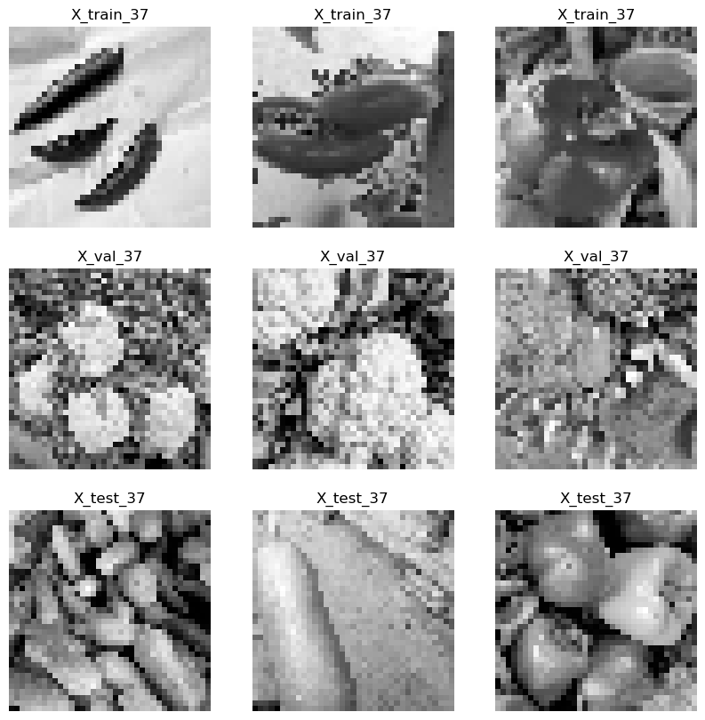

```python
# Show an example of 37 pixel to 37 pixel

plt.figure(figsize=(10, 10))

for i in range(3):

    plt.subplot(3, 3, i+1)
    plt.imshow(X_train_37[i], cmap=plt.get_cmap('gray'))
    plt.axis('off')
    plt.title("X_train_37")

for i in range(3):
    plt.subplot(3, 3, i+4)
    plt.imshow(X_val_37[i], cmap=plt.get_cmap('gray'))
    plt.axis('off')
    plt.title("X_val_37")


for i in range(3):
    plt.subplot(3, 3, i+7)
    plt.imshow(X_test_37[i], cmap=plt.get_cmap('gray'))
    plt.axis('off')
    plt.title("X_test_37")


plt.show()
```

### a iv) Rebalance class weight for 37 by 37 pixel

```python
# CLass weight is imbalance. Use class weight to balance it out
from sklearn.utils.class_weight import compute_class_weight
from sklearn.preprocessing import MultiLabelBinarizer

def generate_class_weights(class_series):
    class_series = np.argmax(class_series, axis=1)

    class_labels = np.unique(class_series)
    class_weights = compute_class_weight(class_weight='balanced', classes=class_labels, y=class_series)
    return dict(zip(class_labels, class_weights))

labels = y_train_37
class_weights_37 = generate_class_weights(labels)
```

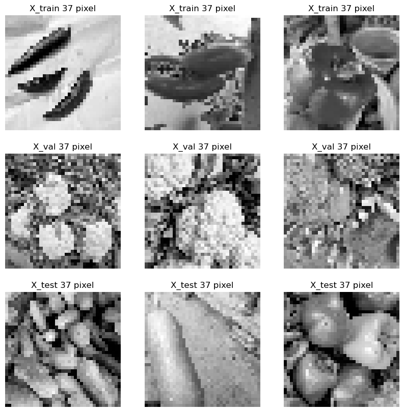

```python
# Show an example of 37 pixel to 37 pixel of a X_train_37

plt.figure(figsize=(10, 10))

for i in range(3):

    plt.subplot(3, 3, i+1)
    plt.imshow(X_train_37[i], cmap=plt.get_cmap('gray'))
    plt.axis('off')
    plt.title("X_train 37 pixel")

for i in range(3):
    plt.subplot(3, 3, i+4)
    plt.imshow(X_val_37[i], cmap=plt.get_cmap('gray'))
    plt.axis('off')
    plt.title("X_val 37 pixel")


for i in range(3):
    plt.subplot(3, 3, i+7)
    plt.imshow(X_test_37[i], cmap=plt.get_cmap('gray'))
    plt.axis('off')
    plt.title("X_test 37 pixel")


plt.show()
```

# b) 131 by 131 pixels

## b i) Pre-process images

```python
# train_dataset_131
train_dataset_131 = normalize.flow_from_directory('train',target_size=(131, 131),
        color_mode='grayscale',
        batch_size=10000,
        class_mode='categorical')

# Validation_dataset_131
val_dataset_131 = normalize.flow_from_directory('validation',target_size=(131, 131),
        color_mode='grayscale',
        batch_size=5000,
        class_mode='categorical')

# test_dataset_131
test_dataset_131 = normalize.flow_from_directory('validation',target_size=(131, 131),
        color_mode='grayscale',
        batch_size=5000,
        class_mode='categorical')
```

```
Found 9035 images belonging to 15 classes.
Found 3000 images belonging to 15 classes.
Found 3000 images belonging to 15 classes.
```

## b ii) Deal with class for 131 by 131 pixels

```python
# Show the class indices

# Train
print(f'Train_131:\n {train_dataset_131.class_indices}')

# Validation
print(f'\nValidation_131:\n {val_dataset_131.class_indices}')

# Test
print(f'\nTest_131:\n {test_dataset_131.class_indices}')
```

```
Train_131:
 {'Bean': 0, 'Bitter_Gourd': 1, 'Bottle_Gourd': 2, 'Brinjal': 3, 'Broccoli': 4, 'Cabbage': 5, 'Capsicum': 6, 'Carrot': 7, 'Cauliflower': 8, 'Cucumber': 9, 'Papaya': 10, 'Potato': 11, 'Pumpkin': 12, 'Radish': 13, 'Tomato': 14}

Validation_131:
 {'Bean': 0, 'Bitter_Gourd': 1, 'Bottle_Gourd': 2, 'Brinjal': 3, 'Broccoli': 4, 'Cabbage': 5, 'Capsicum': 6, 'Carrot': 7, 'Cauliflower': 8, 'Cucumber': 9, 'Papaya': 10, 'Potato': 11, 'Pumpkin': 12, 'Radish': 13, 'Tomato': 14}

Test_131:
 {'Bean': 0, 'Bitter_Gourd': 1, 'Bottle_Gourd': 2, 'Brinjal': 3, 'Broccoli': 4, 'Cabbage': 5, 'Capsicum': 6, 'Carrot': 7, 'Cauliflower': 8, 'Cucumber': 9, 'Papaya': 10, 'Potato': 11, 'Pumpkin': 12, 'Radish': 13, 'Tomato': 14}
```

```python
# Show the classes

# Train
print(f'Train_131:\n {train_dataset_131.classes}')

# Validation
print(f'\nValidation_131:\n {val_dataset_131.classes}')

# Test
print(f'\nTest_131:\n {test_dataset_131.classes}')
```

```
Train_131:
 [ 0  0  0 ... 14 14 14]

Validation_131:
 [ 0  0  0 ... 14 14 14]

Test_131:
 [ 0  0  0 ... 14 14 14]
```

## b iii) Convert train, validation and test dataset into X_train_131, y_train_131, X_val_131, y_val_131, X_test_131, y_test_131

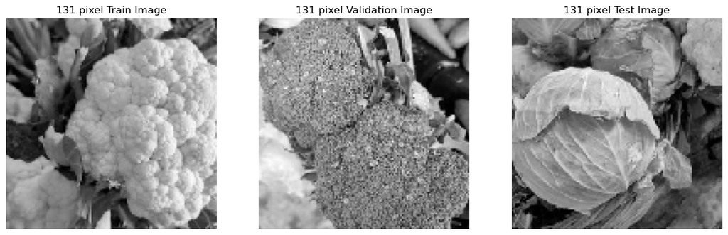

```python
# Show how the image in train_dataset_131, validation_dataset_big and test_dataset_131 look like

# Get image from the train_dataset
X_train_131, y_train_131 = next(train_dataset_131)

# Get image from the validation_dataset
X_val_131, y_val_131 = next(val_dataset_131)

# Get image from the test_dataset_131
X_test_131, y_test_131 = next(test_dataset_131)

fig, ax = plt.subplots(1, 3, figsize=(15, 5))

# Display the first image for train, val and test
ax[0].imshow(X_train_131[0], cmap = 'gray')
ax[0].set_title('131 pixel Train Image')


ax[1].imshow(X_val_131[0], cmap = 'gray')
ax[1].set_title('131 pixel Validation Image')

ax[2].imshow(X_test_131[0], cmap = 'gray')
ax[2].set_title('131 pixel Test Image')


ax[0].axis('off')
ax[1].axis('off')
ax[2].axis('off')

plt.show()
```

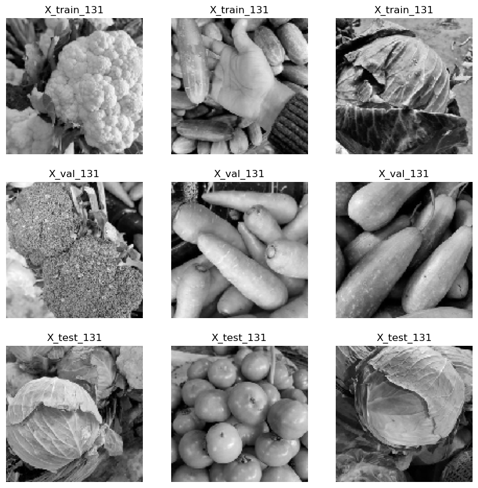

```python
# Show an example of 131 pixel to 131 pixel

plt.figure(figsize=(10, 10))

for i in range(3):

    plt.subplot(3, 3, i+1)
    plt.imshow(X_train_131[i], cmap=plt.get_cmap('gray'))
    plt.axis('off')
    plt.title("X_train_131")

for i in range(3):
    plt.subplot(3, 3, i+4)
    plt.imshow(X_val_131[i], cmap=plt.get_cmap('gray'))
    plt.axis('off')
    plt.title("X_val_131")


for i in range(3):
    plt.subplot(3, 3, i+7)
    plt.imshow(X_test_131[i], cmap=plt.get_cmap('gray'))
    plt.axis('off')
    plt.title("X_test_131")


plt.show()
```

## b iv) Rebalance class weight for 131 pixel

```python
# CLass weight is imbalance. Use class weight to balance it out
from sklearn.utils.class_weight import compute_class_weight
from sklearn.preprocessing import MultiLabelBinarizer

def generate_class_weights(class_series):
    class_series = np.argmax(class_series, axis=1)

    class_labels = np.unique(class_series)
    class_weights = compute_class_weight(class_weight='balanced', classes=class_labels, y=class_series)
    return dict(zip(class_labels, class_weights))

labels = y_train_131
class_weight_131 = generate_class_weights(labels)
```

# 3) Modeling and evaluation

```python
# Import necessary modules for modelling and evaluation

from tensorflow.keras.models import Sequential
from tensorflow.keras.layers import Dense
from tensorflow.keras.layers import Dropout
from tensorflow.keras.layers import Flatten
from tensorflow.keras.layers import Conv2D
from tensorflow.keras.layers import MaxPooling2D
from tensorflow.keras.layers import BatchNormalization

from tensorflow.keras import regularizers
from keras.optimizers import Adam
from tensorflow.keras.optimizers import SGD
```

# a) 37 pixel by 37 pixel

```python
# Get the number of class for y_train
num_classes = y_train_37.shape[1]
```

```python
# Reshape every X so it can be fit into the model
X_train_37 = X_train_37.reshape(X_train_37.shape[0], 37, 37, 1).astype('float32')
X_test_37 = X_test_37.reshape(X_test_37.shape[0], 37, 37, 1).astype('float32')
X_val_37 = X_val_37.reshape(X_val_37.shape[0], 37, 37, 1).astype('float32')
```

## a i) Base Model 37 by 37 pixel

We create a base model with some layers first and see how it works.

```python
model_37 = Sequential()

model_37.add(Conv2D(64, (5, 5), input_shape=(37, 37, 1), activation='relu'))
model_37.add(Conv2D(16, (3, 3), activation='relu'))
model_37.add(MaxPooling2D(pool_size=(2, 2)))
model_37.add(Flatten())
model_37.add(Dense(64, activation='relu'))

model_37.add(Dense(64, activation='relu'))
model_37.add(Dense(num_classes, activation='softmax'))
```

```python
# Optimizer will be adam

model_37.compile(loss='categorical_crossentropy',
 optimizer='adam', metrics=['accuracy'])
```

```python
# Show the summary for model 37 pixel
model_37.summary()
```

```
Model: "sequential"
_________________________________________________________________
 Layer (type)                Output Shape              Param #
=================================================================
 conv2d (Conv2D)             (None, 33, 33, 64)        1664

 conv2d_1 (Conv2D)           (None, 31, 31, 16)        9232

 max_pooling2d (MaxPooling2D  (None, 15, 15, 16)       0
 )

 flatten (Flatten)           (None, 3600)              0

 dense (Dense)               (None, 64)                230464

 dense_1 (Dense)             (None, 64)                4160

 dense_2 (Dense)             (None, 15)                975

=================================================================
Total params: 246,495
Trainable params: 246,495
Non-trainable params: 0
_________________________________________________________________
```

```python
# Train model base 37 pixel
history_37 = model_37.fit(X_train_37, y_train_37, validation_data=(X_val_37, y_val_37),
 epochs=50, verbose=1, batch_size = 150, class_weight = class_weights_37)
```

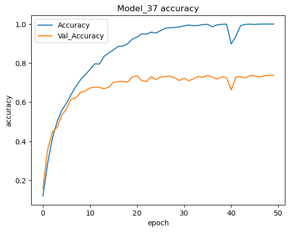

```python
# Show history of 37 pixel model for accuracy
plt.plot(history_37.history['accuracy'])
plt.plot(history_37.history['val_accuracy'])
plt.title('Model_37 accuracy')
plt.ylabel('accuracy')
plt.xlabel('epoch')
plt.legend(['Accuracy', 'Val_Accuracy'], loc='upper left')
plt.show()
```

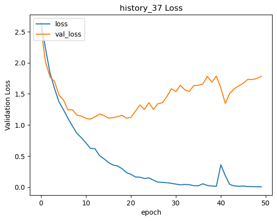

```python
# Show history of 37 pixel model for loss
plt.plot(history_37.history['loss'])
plt.plot(history_37.history['val_loss'])
plt.title('history_37 Loss')
plt.ylabel('Validation Loss')
plt.xlabel('epoch')
plt.legend(['loss', 'val_loss'], loc='upper left')
plt.show()
```

For accuracy, there seems to be an overfit for model 37 accuracy and loss. To prevent that and to increase accuracy and reduce lose, we will hypertune it by adding layers.

## ii) Hyperparameter tuning model 37 by 37 pixel (Add some layers) and optimizer

```python
l2_strength = 0.001  # Adjusted for experimentation

model_37_tune = Sequential()

# Adding more convolutional layers with increased filter sizes
model_37_tune.add(Conv2D(32, (5, 5), input_shape=(37, 37, 1), activation='relu'))
model_37_tune.add(BatchNormalization())
model_37_tune.add(MaxPooling2D(pool_size=(2, 2)))

model_37_tune.add(Conv2D(64, (5, 5), activation='relu'))
model_37_tune.add(BatchNormalization())
model_37_tune.add(MaxPooling2D(pool_size=(2, 2)))
model_37_tune.add(Dropout(0.5))

model_37_tune.add(Conv2D(128, (3, 3), activation='relu', kernel_regularizer=regularizers.l2(l2_strength)))
model_37_tune.add(BatchNormalization())
model_37_tune.add(MaxPooling2D(pool_size=(2, 2)))

# Using Global Average Pooling instead of Flatten
model_37_tune.add(Flatten())

# Dense layers with Dropout
model_37_tune.add(Dense(128, activation='relu', kernel_regularizer=regularizers.l2(l2_strength)))
model_37_tune.add(Dropout(0.5))

model_37_tune.add(Dense(64, activation='relu', kernel_regularizer=regularizers.l2(l2_strength)))

model_37_tune.add(Dense(num_classes, activation='softmax'))

# Optimizer will be SGD
optimizer = SGD(learning_rate=0.0001, momentum = 0.8)

model_37_tune.compile(loss='categorical_crossentropy',
 optimizer=optimizer, metrics=['accuracy'])

# Show the summary for model 37 pixel hypertuned
model_37_tune.summary()
```

```
Model: "sequential_1"
_________________________________________________________________
 Layer (type)                Output Shape              Param #
=================================================================
 conv2d_2 (Conv2D)           (None, 33, 33, 32)        832

 batch_normalization (BatchN  (None, 33, 33, 32)       128
 ormalization)

 max_pooling2d_1 (MaxPooling  (None, 16, 16, 32)       0
 2D)

 conv2d_3 (Conv2D)           (None, 12, 12, 64)        51264

 batch_normalization_1 (Batc  (None, 12, 12, 64)       256
 hNormalization)

 max_pooling2d_2 (MaxPooling  (None, 6, 6, 64)         0
 2D)

 dropout (Dropout)           (None, 6, 6, 64)          0

 conv2d_4 (Conv2D)           (None, 4, 4, 128)         73856

 batch_normalization_2 (Batc  (None, 4, 4, 128)        512
 hNormalization)

 max_pooling2d_3 (MaxPooling  (None, 2, 2, 128)        0
 2D)

 flatten_1 (Flatten)         (None, 512)               0

 dense_3 (Dense)             (None, 128)               65664

 dropout_1 (Dropout)         (None, 128)               0

 dense_4 (Dense)             (None, 64)                8256

 dense_5 (Dense)             (None, 15)                975

=================================================================
Total params: 201,743
Trainable params: 201,295
Non-trainable params: 448
_________________________________________________________________
```

```python
# Train model 37 pixel hypertune
history_37_tune = model_37_tune.fit(X_train_37, y_train_37, validation_data=(X_val_37, y_val_37),
 epochs=50, verbose=1, batch_size = 50, class_weight = class_weights_37)
```

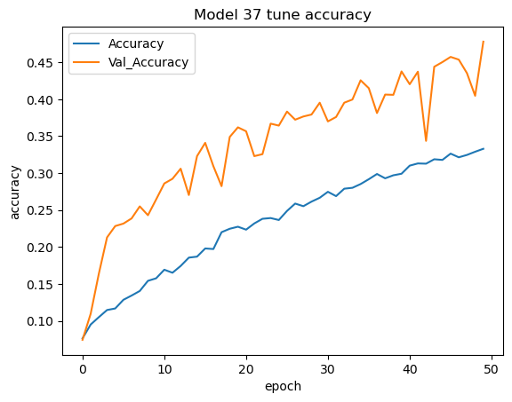

```python
# Show history of 37 pixel hypertune model for accuracy

plt.plot(history_37_tune.history['accuracy'])
plt.plot(history_37_tune.history['val_accuracy'])
plt.title('Model 37 tune accuracy')
plt.ylabel('accuracy')
plt.xlabel('epoch')
plt.legend(['Accuracy', 'Val_Accuracy'], loc='upper left')
plt.show()
```

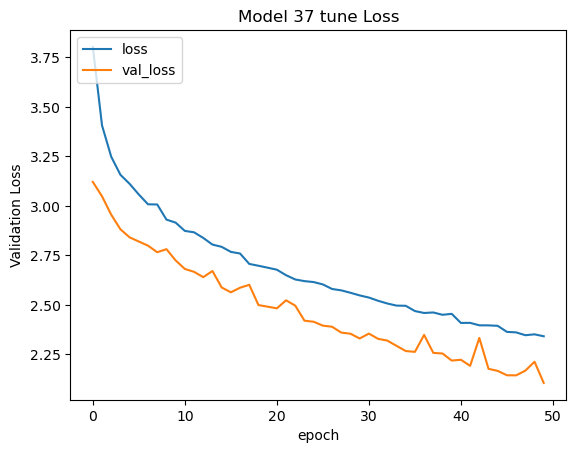

```python
# Show history of 37 pixel model for loss
plt.plot(history_37_tune.history['loss'])
plt.plot(history_37_tune.history['val_loss'])
plt.title('Model 37 tune Loss')
plt.ylabel('Validation Loss')
plt.xlabel('epoch')
plt.legend(['loss', 'val_loss'], loc='upper left')
plt.show()
```

## iii) Change the optimizer.

We will change the optimizer to adam

```python
l2_strength = 0.001  # Adjusted for experimentation

model_37_tune_2 = Sequential()

# Adding more convolutional layers with increased filter sizes
model_37_tune_2.add(Conv2D(32, (5, 5), input_shape=(37, 37, 1), activation='relu'))
model_37_tune_2.add(BatchNormalization())
model_37_tune_2.add(MaxPooling2D(pool_size=(2, 2)))

model_37_tune_2.add(Conv2D(64, (5, 5), activation='relu'))
model_37_tune_2.add(BatchNormalization())
model_37_tune_2.add(MaxPooling2D(pool_size=(2, 2)))
model_37_tune_2.add(Dropout(0.5))

model_37_tune_2.add(Conv2D(128, (3, 3), activation='relu', kernel_regularizer=regularizers.l2(l2_strength)))
model_37_tune_2.add(BatchNormalization())
model_37_tune_2.add(MaxPooling2D(pool_size=(2, 2)))

# Using Global Average Pooling instead of Flatten
model_37_tune_2.add(Flatten())

# Dense layers with Dropout
model_37_tune_2.add(Dense(128, activation='relu', kernel_regularizer=regularizers.l2(l2_strength)))
model_37_tune_2.add(Dropout(0.5))

model_37_tune_2.add(Dense(64, activation='relu', kernel_regularizer=regularizers.l2(l2_strength)))

model_37_tune_2.add(Dense(num_classes, activation='softmax'))

# Optimizer will be Adam
optimizer = Adam(learning_rate=0.0001)

model_37_tune_2.compile(loss='categorical_crossentropy',
 optimizer=optimizer, metrics=['accuracy'])

# Show the summary for model 37 pixel hypertuned
model_37_tune_2.summary()
```

```
Model: "sequential_3"
_________________________________________________________________
 Layer (type)                Output Shape              Param #
=================================================================
 conv2d_8 (Conv2D)           (None, 33, 33, 32)        832

 batch_normalization_6 (Batc  (None, 33, 33, 32)       128
 hNormalization)

 max_pooling2d_8 (MaxPooling  (None, 16, 16, 32)       0
 2D)

 conv2d_9 (Conv2D)           (None, 12, 12, 64)        51264

 batch_normalization_7 (Batc  (None, 12, 12, 64)       256
 hNormalization)

 max_pooling2d_9 (MaxPooling  (None, 6, 6, 64)         0
 2D)

 dropout_5 (Dropout)         (None, 6, 6, 64)          0

 conv2d_10 (Conv2D)          (None, 4, 4, 128)         73856

 batch_normalization_8 (Batc  (None, 4, 4, 128)        512
 hNormalization)

 max_pooling2d_10 (MaxPoolin  (None, 2, 2, 128)        0
 g2D)

 flatten_3 (Flatten)         (None, 512)               0

 dense_8 (Dense)             (None, 128)               65664

 dropout_6 (Dropout)         (None, 128)               0

 dense_9 (Dense)             (None, 64)                8256

 dense_10 (Dense)            (None, 15)                975

=================================================================
Total params: 201,743
Trainable params: 201,295
Non-trainable params: 448
_________________________________________________________________
```

```python
# Train model 37 pixel hypertune
history_37_tune_2 = model_37_tune_2.fit(X_train_37, y_train_37, validation_data=(X_val_37, y_val_37),
 epochs=180, verbose=1, batch_size = 50, class_weight = class_weights_37)
```

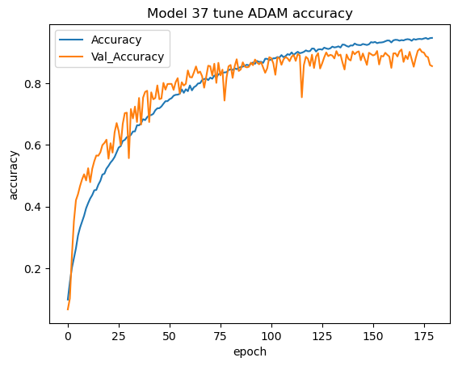

```python
# Show history of 37 pixel hypertune model for accuracy

plt.plot(history_37_tune_2.history['accuracy'])
plt.plot(history_37_tune_2.history['val_accuracy'])
plt.title('Model 37 tune ADAM accuracy')
plt.ylabel('accuracy')
plt.xlabel('epoch')
plt.legend(['Accuracy', 'Val_Accuracy'], loc='upper left')
plt.show()
```

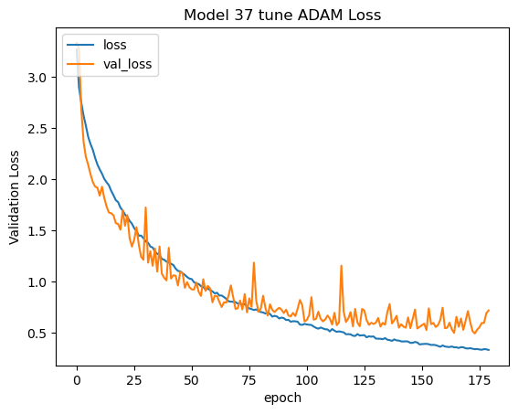

```python
# Show history of 37 pixel model for loss
plt.plot(history_37_tune_2.history['loss'])
plt.plot(history_37_tune_2.history['val_loss'])
plt.title('Model 37 tune ADAM Loss')
plt.ylabel('Validation Loss')
plt.xlabel('epoch')
plt.legend(['loss', 'val_loss'], loc='upper left')
plt.show()
```

Its less overfit now and the accuracy increases too.

# b) 131 x 131 Model

```python
# Reshape every X so it can be fit into the model
X_train_131 = X_train_131.reshape(X_train_131.shape[0], 131, 131, 1).astype('float32')
X_test_131 = X_test_131.reshape(X_test_131.shape[0], 131, 131, 1).astype('float32')
X_val_131 = X_val_131.reshape(X_val_131.shape[0], 131, 131, 1).astype('float32')

num_classes_131 = y_train_131.shape[1]
```

```python
print(X_val_131.shape)
```

```
(3000, 131, 131, 1)
```

### i) Base Model 131 by 131 pixel

```python
model_131 = Sequential()

model_131.add(Conv2D(64, (5, 5), input_shape=(131, 131, 1), activation='relu'))
model_131.add(MaxPooling2D(pool_size=(2, 2)))

model_131.add(Conv2D(64, (3, 3), activation='relu'))
model_131.add(Flatten())

model_131.add(Dense(32, activation='relu'))
model_131.add(Dense(num_classes_131, activation='softmax'))
```

```python
# Optimizer will be adam

model_131.compile(loss='categorical_crossentropy',
 optimizer='adam', metrics=['accuracy'])
```

```python
# Show the summary for model 131 pixel
model_131.summary()
```

```
Model: "sequential_8"
_________________________________________________________________
 Layer (type)                Output Shape              Param #
=================================================================
 conv2d_22 (Conv2D)          (None, 127, 127, 64)      1664

 max_pooling2d_20 (MaxPoolin  (None, 63, 63, 64)       0
 g2D)

 conv2d_23 (Conv2D)          (None, 61, 61, 64)        36928

 flatten_8 (Flatten)         (None, 238144)            0

 dense_23 (Dense)            (None, 32)                7620640

 dense_24 (Dense)            (None, 15)                495

=================================================================
Total params: 7,659,727
Trainable params: 7,659,727
Non-trainable params: 0
_________________________________________________________________
```

```python
# Train model 131
history_131 = model_131.fit(X_train_131, y_train_131, validation_data=(X_val_131, y_val_131),
 epochs=50, verbose=1, batch_size = 20, class_weight = class_weight_131)
```

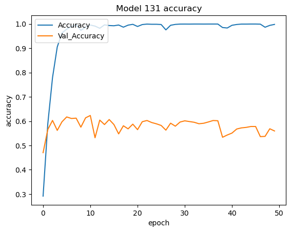

```python
# base model 131 pixel accuracy
plt.plot(history_131.history['accuracy'])
plt.plot(history_131.history['val_accuracy'])
plt.title('Model 131 accuracy')
plt.ylabel('accuracy')
plt.xlabel('epoch')
plt.legend(['Accuracy', 'Val_Accuracy'], loc='upper left')
plt.show()
```

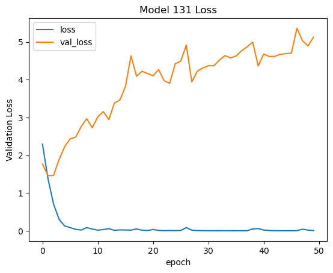

```python
# base model 131 pixel loss
plt.plot(history_131.history['loss'])
plt.plot(history_131.history['val_loss'])
plt.title('Model 131 Loss')
plt.ylabel('Validation Loss')
plt.xlabel('epoch')
plt.legend(['loss', 'val_loss'], loc='upper left')
plt.show()
```

The accuracy and loss it way too overfit and does not produce a good results. I decide to hypertune it.

## ii) Hypertune model 131 by 131 pixel

We going to add more layers and use lasso regularization. Not only that, we will use SGD.

```python
l1_strength = 0.001  # You can adjust this value based on experimentation


model_131_tune = Sequential()


model_131_tune.add(Conv2D(64, (5, 5), input_shape=(131, 131, 1), activation='relu'))
model_131_tune.add(MaxPooling2D(pool_size=(2, 2)))
model_131_tune.add(Conv2D(64, (3, 3), activation='relu'))
model_131_tune.add(MaxPooling2D(pool_size=(2, 2)))
model_131_tune.add(Flatten())
model_131_tune.add(Dropout(0.5))  # Adding dropout before final dense layers

model_131_tune.add(Dense(32, activation='relu', kernel_regularizer=regularizers.l1(l1_strength)))
model_131_tune.add(Dense(64, activation='relu', kernel_regularizer=regularizers.l1(l1_strength)))  # Increase number of neurons
model_131_tune.add(Dense(num_classes_131, activation='softmax'))

# Optimizer will be adam
optimizer = SGD(learning_rate=0.0001, momentum = 0.05)  # You can adjust the learning rate as needed

model_131_tune.compile(loss='categorical_crossentropy',
 optimizer=optimizer, metrics=['accuracy'])

# Show the summary for model 131 pixel
model_131_tune.summary()
```

```
Model: "sequential_9"
_________________________________________________________________
 Layer (type)                Output Shape              Param #
=================================================================
 conv2d_24 (Conv2D)          (None, 127, 127, 64)      1664

 max_pooling2d_21 (MaxPoolin  (None, 63, 63, 64)       0
 g2D)

 conv2d_25 (Conv2D)          (None, 61, 61, 64)        36928

 max_pooling2d_22 (MaxPoolin  (None, 30, 30, 64)       0
 g2D)

 flatten_9 (Flatten)         (None, 57600)             0

 dropout_12 (Dropout)        (None, 57600)             0

 dense_25 (Dense)            (None, 32)                1843232

 dense_26 (Dense)            (None, 64)                2112

 dense_27 (Dense)            (None, 15)                975

=================================================================
Total params: 1,884,911
Trainable params: 1,884,911
Non-trainable params: 0
_________________________________________________________________
```

```python
## History of 131 pixel tune model
history_131_tune = model_131_tune.fit(X_train_131, y_train_131, validation_data=(X_val_131, y_val_131),
 epochs=50, verbose=1, batch_size = 30, class_weight = class_weight_131)
```

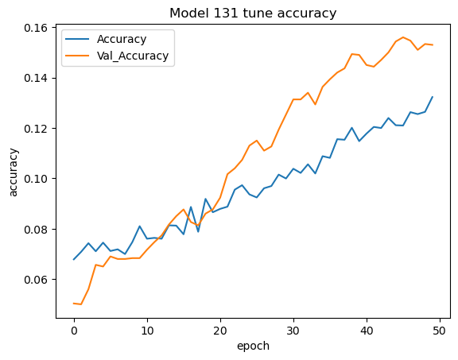

```python
# History of 131 pixel tune model accuracy
plt.plot(history_131_tune.history['accuracy'])
plt.plot(history_131_tune.history['val_accuracy'])
plt.title('Model 131 tune accuracy')
plt.ylabel('accuracy')
plt.xlabel('epoch')
plt.legend(['Accuracy', 'Val_Accuracy'], loc='upper left')
plt.show()
```

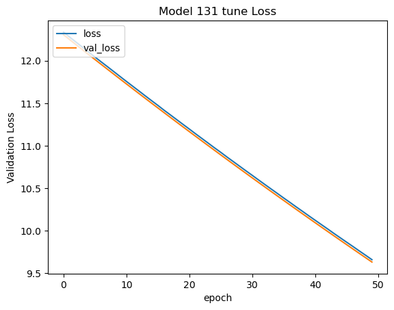

```python
# History of 131 pixel tune model loss
plt.plot(history_131_tune.history['loss'])
plt.plot(history_131_tune.history['val_loss'])
plt.title('Model 131 tune Loss')
plt.ylabel('Validation Loss')
plt.xlabel('epoch')
plt.legend(['loss', 'val_loss'], loc='upper left')
plt.show()
```

Seems like the SGD optimizer might not be a good idea. Thus, we should try change optimizer instead

## iii) Change optimizer for 131 by 131 pixel

```python
l1_strength = 0.001  # You can adjust this value based on experimentation


model_131_tune_2 = Sequential()


model_131_tune_2.add(Conv2D(64, (5, 5), input_shape=(131, 131, 1), activation='relu'))
model_131_tune_2.add(MaxPooling2D(pool_size=(2, 2)))
model_131_tune_2.add(Conv2D(64, (3, 3), activation='relu'))
model_131_tune_2.add(MaxPooling2D(pool_size=(2, 2)))
model_131_tune_2.add(Flatten())
model_131_tune_2.add(Dropout(0.5))  # Adding dropout before final dense layers

model_131_tune_2.add(Dense(32, activation='relu', kernel_regularizer=regularizers.l1(l1_strength)))
model_131_tune_2.add(Dense(64, activation='relu', kernel_regularizer=regularizers.l1(l1_strength)))  # Increase number of neurons
model_131_tune_2.add(Dense(num_classes_131, activation='softmax'))

# Optimizer will be adam
optimizer = Adam(learning_rate=0.0001)  # You can adjust the learning rate as needed

model_131_tune_2.compile(loss='categorical_crossentropy',
 optimizer=optimizer, metrics=['accuracy'])

# Show the summary for model 131 pixel
model_131_tune_2.summary()
```

```
Model: "sequential_5"
_________________________________________________________________
 Layer (type)                Output Shape              Param #
=================================================================
 conv2d_13 (Conv2D)          (None, 127, 127, 64)      1664

 max_pooling2d_13 (MaxPoolin  (None, 63, 63, 64)       0
 g2D)

 conv2d_14 (Conv2D)          (None, 61, 61, 64)        36928

 max_pooling2d_14 (MaxPoolin  (None, 30, 30, 64)       0
 g2D)

 flatten_5 (Flatten)         (None, 57600)             0

 dropout_8 (Dropout)         (None, 57600)             0

 dense_13 (Dense)            (None, 32)                1843232

 dense_14 (Dense)            (None, 64)                2112

 dense_15 (Dense)            (None, 15)                975

=================================================================
Total params: 1,884,911
Trainable params: 1,884,911
Non-trainable params: 0
_________________________________________________________________
```

```python
#### History of 131 pixel tune model
history_131_tune = model_131_tune_2.fit(X_train_131, y_train_131, validation_data=(X_val_131, y_val_131),
 epochs=400, verbose=1, batch_size = 30, class_weight = class_weight_131)
```

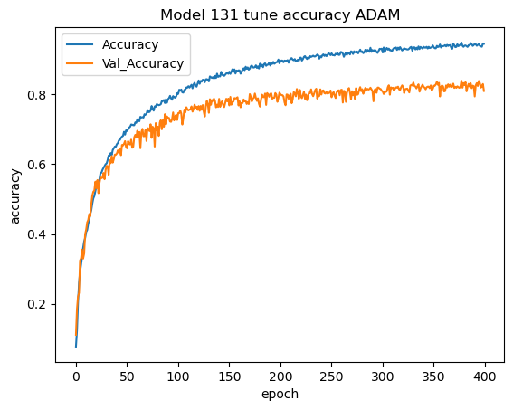

```python
# History of 131 pixel tune model accuracy
plt.plot(history_131_tune.history['accuracy'])
plt.plot(history_131_tune.history['val_accuracy'])
plt.title('Model 131 tune accuracy ADAM')
plt.ylabel('accuracy')
plt.xlabel('epoch')
plt.legend(['Accuracy', 'Val_Accuracy'], loc='upper left')
plt.show()
```

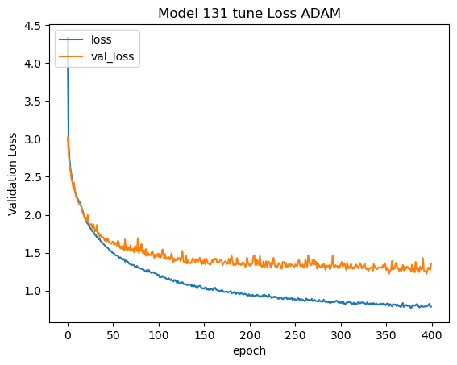

```python
# History of 131 pixel tune model loss
plt.plot(history_131_tune.history['loss'])
plt.plot(history_131_tune.history['val_loss'])
plt.title('Model 131 tune Loss ADAM')
plt.ylabel('Validation Loss')
plt.xlabel('epoch')
plt.legend(['loss', 'val_loss'], loc='upper left')
plt.show()
```

# 4) Model Evaluation

```python
from keras.utils.vis_utils import plot_model
from sklearn.metrics import classification_report
```

Change directory to one folder above to store the best model

```python
os.chdir('../')
```

```python
# Save model for 37 pixel
model_37_tune_2.save("model37tune_2.h5")
```

```python
# Save model weights for 37 pixel
model_37_tune_2.save("model37tune_2_weights.h5")
```

## a) 37 pixel Model

model_37_tune_2 has best validation metrics and least overfitting.

```python
model_37_tune_2_loaded = tf.keras.models.load_model("model37tune_2.h5")
```

```python
scores = model_37_tune_2_loaded.evaluate(X_test_37, y_test_37)

print(f"\n Accuracy: {round(scores[1]*100, 2)}%")
```

```
 Accuracy: 85.6%
```

```python
# Predict classes for the test set
y_pred_37 = model_37_tune_2_loaded.predict(X_test_37)

# Convert predicted probabilities to class labels
y_pred_classes_37 = np.argmax(y_pred_37, axis=1)
```

## i) Classification Report

```python
# Print classification report
print("\nClassification Report:")
print(classification_report(y_test_37.argmax(axis=1), y_pred_classes_37))
```

```
Classification Report:
              precision    recall  f1-score   support

           0       0.76      0.93      0.84       200
           1       0.95      0.89      0.91       200
           2       0.96      0.90      0.93       200
           3       0.85      0.82      0.83       200
           4       0.93      0.79      0.85       200
           5       0.93      0.64      0.76       200
           6       0.79      0.93      0.86       200
           7       0.72      0.99      0.83       200
           8       0.87      0.81      0.84       200
           9       0.90      0.87      0.89       200
          10       0.87      0.89      0.88       200
          11       0.84      0.91      0.87       200
          12       0.91      0.77      0.83       200
          13       0.95      0.83      0.89       200
          14       0.78      0.91      0.84       200

    accuracy                           0.86      3000
   macro avg       0.87      0.86      0.86      3000
weighted avg       0.87      0.86      0.86      3000
```

## ii) Visualise model

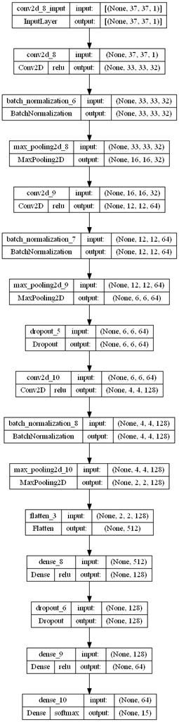

```python
plot_model(model_37_tune_2_loaded, show_shapes=True, expand_nested=True, show_layer_activations=True, show_layer_names=True)
```

## b) 131 pixel Model

model_131_tune_2 has best validation metrics and least overfitting.

```python
# Save model for 131 pixel
model_131_tune_2.save("model131tune_2.h5")
```

```python
# Save model weights for 131 pixel
model_131_tune_2.save_weights("model131tune_2_weights.h5")
```

```python
model_131_tune_2_loaded = tf.keras.models.load_model("model131tune_2.h5")
```

```python
scores = model_131_tune_2_loaded.evaluate(X_test_131, y_test_131)

print(f"\n Accuracy: {round(scores[1]*100, 2)}%")
```

```
 Accuracy: 81.03%
```

```python
# Predict classes for the test set
y_pred_131 = model_131_tune_2_loaded.predict(X_test_131)

# Convert predicted probabilities to class labels
y_pred_classes_131 = np.argmax(y_pred_131, axis=1)
```

## i) Classification Report

```python
# Print classification report
print("\nClassification Report:")
print(classification_report(y_test_131.argmax(axis=1), y_pred_classes_131))
```

```
Classification Report:
              precision    recall  f1-score   support

           0       0.79      0.71      0.75       200
           1       0.87      0.94      0.90       200
           2       0.87      0.83      0.85       200
           3       0.75      0.81      0.78       200
           4       0.94      0.73      0.83       200
           5       0.75      0.72      0.74       200
           6       0.74      0.91      0.81       200
           7       0.89      0.91      0.90       200
           8       0.89      0.60      0.72       200
           9       0.75      0.85      0.80       200
          10       0.76      0.88      0.82       200
          11       0.84      0.78      0.81       200
          12       0.85      0.80      0.82       200
          13       0.85      0.81      0.83       200
          14       0.72      0.88      0.79       200

    accuracy                           0.81      3000
   macro avg       0.82      0.81      0.81      3000
weighted avg       0.82      0.81      0.81      3000
```

## i) Visualise Model

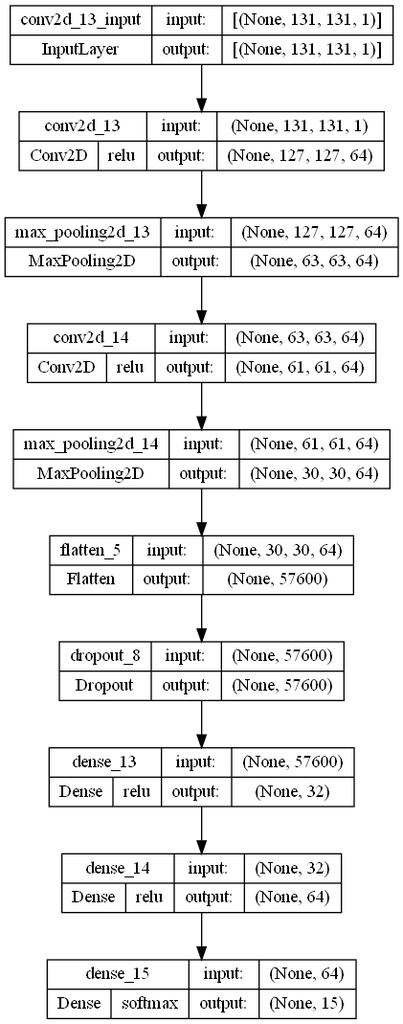

```python
plot_model(model_131_tune_2_loaded, show_shapes=True, expand_nested=True, show_layer_activations=True, show_layer_names=True)
```